# Graph gallery: SGD metric MDS

This gallery fits the same six graph families as the multiscale GRIP gallery, using SGD metric MDS. Graphs, edge lengths and seeds are retained so their representations are easy to compare. This is an illustration, not a controlled benchmark of optimizer quality or runtime. All SGD fits here use three dimensions; the preserved GRIP tree example uses two.

Installed figures use static projections. To enable 3D rotation and layout selection, render with `options(grip.vignette.interactive = TRUE)` and **ivue** and **rgl** installed.

Each fit uses weighted graph shortest-path distances, uniform pair weights, and full metric MDS with the SGD backend. The examples are small enough for full distances. No edge-KK refinement follows MDS. For larger graphs see sparse SGD.

The reference coordinates generate edge lengths; they are not the MDS targets. Shortest-path distances need not admit an exact Euclidean representation, so a fitted layout can differ from the reference geometry even with low stress. The ivue viewers support rotation, zoom and selection of displayed geometries. Coordinates are centered for display without rotation or scale fitting; these are not aligned shape-recovery comparisons. The parameter grid is planar and is displayed at z = 0. Install `ivue` and `rgl` to build the interactive views.

```r
library(grip)
```

## Family classes at a glance

The table below lists a representative subset of the larger family collection.

| Family class | Representative helper | Why it matters |
| --- | --- | --- |
| Lifted lattices | `mesh.surface.graph()` | Plain topology, nontrivial metric geometry |
| Wrapped surfaces | `torus.surface.graph()` | Closed periodic surface geometry |
| Recursive fractals | `vicsek.surface.graph()` | Self-similar bottlenecks and holes |
| Irregular manifolds | `irregular.annulus.surface.graph()` | Non-lattice surface geometry with boundary |
| Porous 3D families | `cube.channel.network.surface.graph()` | Volumetric geodesic detours |
| Intrinsic trees | `kary.tree.weighted.graph()` | Geometry from edge lengths rather than ambient space |

This article shows one representative example from each class. The interactive family browser described in `Interactive Exploration with gripui` exposes a much larger catalog.

## Lifted lattices

The simplest geometry-rich family keeps the graph topology of a rectangular mesh but induces edge lengths from a curved embedding in `R^3`.

```r
mesh.graph <- mesh.surface.graph(
  5, 5,
  surface = "saddle",
  amplitude = 0.8
)

mesh.fit <- metric.mds(
  edges = mesh.graph$edges,
  n = mesh.graph$n,
  edge.weights = mesh.graph$edge_weights,
  dim = 3,
  seed = 1,
  backend = "sgd", pair.weights = "uniform",
  max.iter = 1000, diagnostics = FALSE
)
mesh.coords <- mesh.fit$coords

mesh.summary <- data.frame(
  family = mesh.graph$family,
  surface = mesh.graph$surface,
  n = mesh.graph$n,
  m = nrow(mesh.graph$edges),
  weight_scale = mesh.graph$weight_scale
)

knitr::kable(mesh.summary, digits = 3)
```

| family | surface | n | m | weight_scale |
| --- | --- | --- | --- | --- |
| mesh | saddle | 25 | 40 | 0.66 |

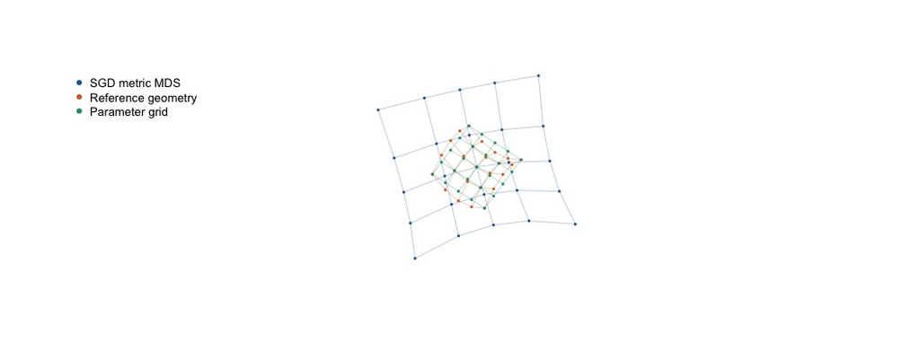

```r
documentation.view(
  list(`SGD metric MDS`=mesh.coords,
       `Reference geometry`=mesh.graph$coords_surface,
       `Parameter grid`=cbind(mesh.graph$coords_param, z=0)),
  edges=mesh.graph$edges, aligned=TRUE,
  description="Mesh: reference and fitted geometries are centered without rotation or scale fitting."
)
```

Mesh: reference and fitted geometries are centered without rotation or scale fitting.

The useful design pattern here is that the topology stays simple while the metric geometry becomes nontrivial.

## Wrapped surfaces

Wrapped lattices extend the same idea to periodic topologies such as a torus.

```r
torus.graph <- torus.surface.graph(
  5, 6,
  surface = "pinched",
  minor.radius = 0.33,
  amplitude = 0.18,
  twist = 0.18
)

torus.fit <- metric.mds(
  edges = torus.graph$edges,
  n = torus.graph$n,
  edge.weights = torus.graph$edge_weights,
  dim = 3,
  seed = 2,
  backend = "sgd", pair.weights = "uniform",
  max.iter = 1000, diagnostics = FALSE
)
torus.coords <- torus.fit$coords

knitr::kable(
  data.frame(
    family = torus.graph$family,
    surface = torus.graph$surface,
    n = torus.graph$n,
    m = nrow(torus.graph$edges)
  )
)
```

| family | surface | n | m |
| --- | --- | --- | --- |
| torus | pinched | 30 | 60 |

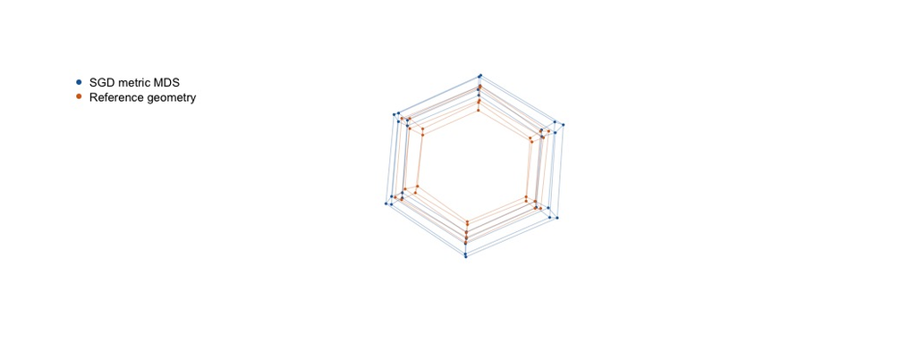

```r
documentation.view(
  list(`SGD metric MDS`=torus.coords,
       `Reference geometry`=torus.graph$coords_surface),
  edges=torus.graph$edges, aligned=TRUE,
  description="Torus: reference and fitted geometries are centered without rotation or scale fitting."
)
```

Torus: reference and fitted geometries are centered without rotation or scale fitting.

These wrapped families are especially useful when ordinary planar intuition is misleading and a 3D layout is the natural target.

## Recursive and fractal families

The package now includes recursive square-mask families such as the Vicsek fractal and Sierpinski carpet variants, all of which can be lifted into curved surface geometries.

```r
vicsek.graph <- vicsek.surface.graph(
  level = 2,
  surface = "ripple",
  amplitude = 0.55
)

vicsek.fit <- metric.mds(
  edges = vicsek.graph$edges,
  n = vicsek.graph$n,
  edge.weights = vicsek.graph$edge_weights,
  dim = 3,
  seed = 3,
  backend = "sgd", pair.weights = "uniform",
  max.iter = 1000, diagnostics = FALSE
)
vicsek.coords <- vicsek.fit$coords
```

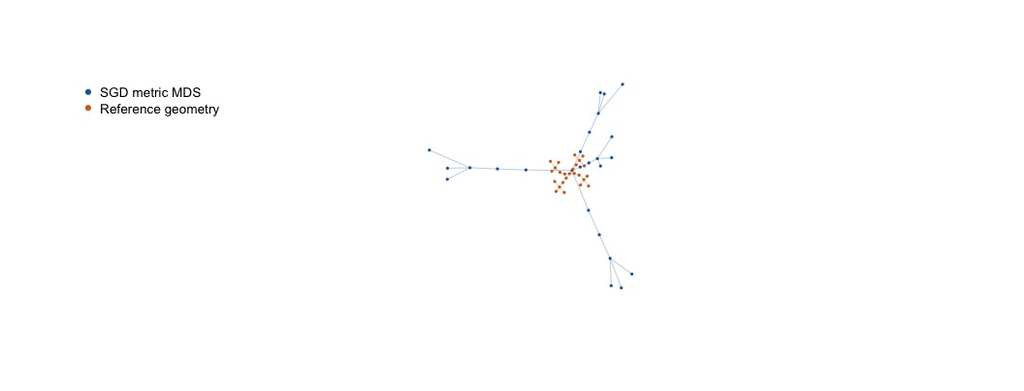

```r
documentation.view(
  list(`SGD metric MDS`=vicsek.coords,
       `Reference geometry`=vicsek.graph$coords_surface),
  edges=vicsek.graph$edges, aligned=TRUE,
  description="Vicsek: reference and fitted geometries are centered without rotation or scale fitting."
)
```

Vicsek: reference and fitted geometries are centered without rotation or scale fitting.

Recursive families are useful because they create holes, bottlenecks, and multi-scale detours that are hard to capture with simpler lattices.

## Irregular manifolds

Not all surface families in `grip` are based on regular grids. The package also includes irregular triangulated manifolds with boundary and closed irregular surfaces.

```r
annulus.graph <- irregular.annulus.surface.graph(
  rings = 5,
  outer.count = 24,
  inner.radius = 0.42,
  surface = "folded",
  amplitude = 0.2
)

annulus.fit <- metric.mds(
  edges = annulus.graph$edges,
  n = annulus.graph$n,
  edge.weights = annulus.graph$edge_weights,
  dim = 3,
  seed = 4,
  backend = "sgd", pair.weights = "uniform",
  max.iter = 1000, diagnostics = FALSE
)
annulus.coords <- annulus.fit$coords
```

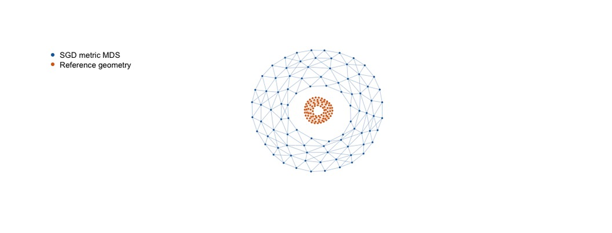

```r
documentation.view(
  list(`SGD metric MDS`=annulus.coords,
       `Reference geometry`=annulus.graph$coords_surface),
  edges=annulus.graph$edges, aligned=TRUE,
  description="Annulus: reference and fitted geometries are centered without rotation or scale fitting."
)
```

Annulus: reference and fitted geometries are centered without rotation or scale fitting.

These families are important because they reduce lattice bias and produce more variable local geometry than mesh-like constructions.

## Porous 3D families

The cubical branch introduces graphs that are genuinely volumetric rather than surface-like. Channel networks and related porous families create 3D geodesic detours that are hard to flatten cleanly.

```r
cube.graph <- cube.channel.network.surface.graph(
  side = 5,
  level = 1,
  surface = "twisted",
  twist = 0.2
)

cube.fit <- metric.mds(
  edges = cube.graph$edges,
  n = cube.graph$n,
  edge.weights = cube.graph$edge_weights,
  dim = 3,
  seed = 5,
  backend = "sgd", pair.weights = "uniform",
  max.iter = 1000, diagnostics = FALSE
)
cube.coords <- cube.fit$coords

knitr::kable(
  data.frame(
    family = cube.graph$family,
    n = cube.graph$n,
    m = nrow(cube.graph$edges)
  )
)
```

| family | n | m |
| --- | --- | --- |
| cube.channel.network | 104 | 212 |

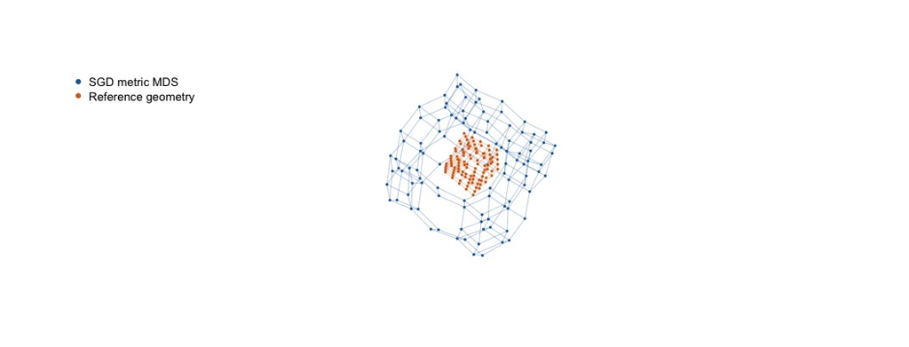

```r
documentation.view(
  list(`SGD metric MDS`=cube.coords,
       `Reference geometry`=cube.graph$coords_surface),
  edges=cube.graph$edges, aligned=TRUE,
  description="Cube: reference and fitted geometries are centered without rotation or scale fitting."
)
```

Cube: reference and fitted geometries are centered without rotation or scale fitting.

This family class is especially useful for testing whether a method can preserve large-scale volumetric structure without collapsing tunnels and channels.

## Intrinsic weighted trees

Some family geometries are intrinsic rather than ambient. The weighted tree helpers preserve the exact tree topology while assigning edge lengths directly from branch-depth and branch-position rules.

```r
tree.graph <- kary.tree.weighted.graph(
  k = 2,
  depth = 4,
  depth.rule = "geometric",
  depth.decay = 0.82,
  branch.rule = "linear",
  branch.spread = 0.25
)

tree.fit <- metric.mds(
  edges = tree.graph$edges,
  n = tree.graph$n,
  edge.weights = tree.graph$edge_weights,
  dim = 3,
  seed = 6,
  backend = "sgd", pair.weights = "uniform",
  max.iter = 1000, diagnostics = FALSE
)
tree.coords <- tree.fit$coords

knitr::kable(
  head(tree.graph$edge_table[, c(
    "parent",
    "child",
    "child_depth",
    "branch_index",
    "edge_weight"
  )]),
  digits = 3
)
```

| parent | child | child_depth | branch_index | edge_weight |
| --- | --- | --- | --- | --- |
| 1 | 2 | 1 | 1 | 1.411 |
| 1 | 3 | 1 | 2 | 1.814 |
| 2 | 4 | 2 | 1 | 1.157 |
| 2 | 5 | 2 | 2 | 1.487 |
| 3 | 6 | 2 | 1 | 1.157 |
| 3 | 7 | 2 | 2 | 1.487 |

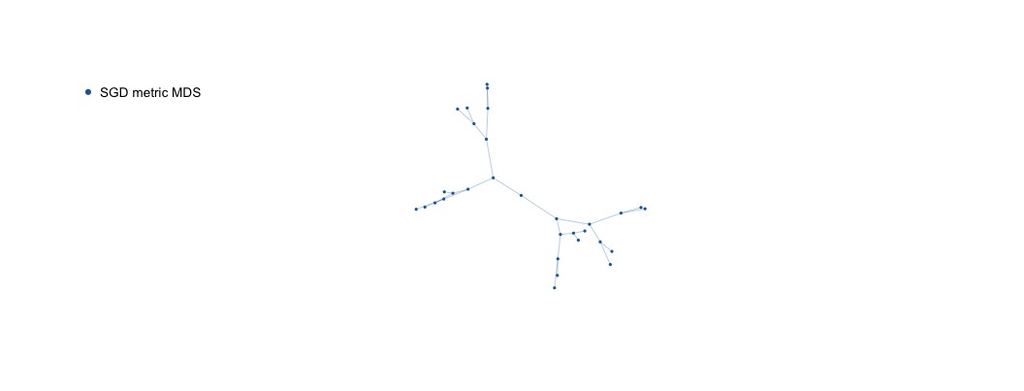

```r
documentation.view(
  list(`SGD metric MDS`=tree.coords),
  edges=tree.graph$edges, aligned=TRUE,
  description="Tree: reference and fitted geometries are centered without rotation or scale fitting."
)
```

Tree: reference and fitted geometries are centered without rotation or scale fitting.

These tree families are useful because they separate intrinsic weighted geometry from any arbitrary 3D embedding choice.

## Stopping status

The table records each fit’s starts. An iteration-limit warning means that coordinates were returned without meeting the stopping criterion; it does not establish convergence or an optimum. Assess graph-distance error and stability across starts before interpreting a layout as evidence about geometry.

```r
fits <- list(Saddle=mesh.fit, Torus=torus.fit, Vicsek=vicsek.fit,
             Annulus=annulus.fit, Porous=cube.fit, Tree=tree.fit)
for (name in names(fits)) {
  cat("\n\n### ", name, "\n\n", sep="")
  print(knitr::kable(fits[[name]]$metadata$starts, digits=5))
}
```

### Saddle

| start | initialization | initial_raw_stress | raw_stress | normalized_stress | iterations | converged | termination | backend_stress | warnings | error | elapsed_seconds | native_seed | pair_updates | best_epoch |
| --- | --- | --- | --- | --- | --- | --- | --- | --- | --- | --- | --- | --- | --- | --- |
| 1 | classical | 55.80461 | 49.18985 | 0.01288 | 1000 | FALSE | iteration_limit | 3.86546 |  |  | 0.037 | 1140350788 | 3e+05 | 907 |

### Torus

| start | initialization | initial_raw_stress | raw_stress | normalized_stress | iterations | converged | termination | backend_stress | warnings | error | elapsed_seconds | native_seed | pair_updates | best_epoch |
| --- | --- | --- | --- | --- | --- | --- | --- | --- | --- | --- | --- | --- | --- | --- |
| 1 | classical | 103.5559 | 65.48395 | 0.0123 | 1000 | FALSE | iteration_limit | 5.34843 |  |  | 0.053 | 794080207 | 435000 | 957 |

### Vicsek

| start | initialization | initial_raw_stress | raw_stress | normalized_stress | iterations | converged | termination | backend_stress | warnings | error | elapsed_seconds | native_seed | pair_updates | best_epoch |
| --- | --- | --- | --- | --- | --- | --- | --- | --- | --- | --- | --- | --- | --- | --- |
| 1 | classical | 70.32794 | 51.06717 | 0.00487 | 1000 | FALSE | iteration_limit | 1.46075 |  |  | 0.037 | 721735354 | 3e+05 | 992 |

### Annulus

| start | initialization | initial_raw_stress | raw_stress | normalized_stress | iterations | converged | termination | backend_stress | warnings | error | elapsed_seconds | native_seed | pair_updates | best_epoch |
| --- | --- | --- | --- | --- | --- | --- | --- | --- | --- | --- | --- | --- | --- | --- |
| 1 | classical | 421.7898 | 280.528 | 0.00239 | 1000 | FALSE | iteration_limit | 9.35364 |  |  | 0.471 | 368509515 | 3916000 | 993 |

### Porous

| start | initialization | initial_raw_stress | raw_stress | normalized_stress | iterations | converged | termination | backend_stress | warnings | error | elapsed_seconds | native_seed | pair_updates | best_epoch |
| --- | --- | --- | --- | --- | --- | --- | --- | --- | --- | --- | --- | --- | --- | --- |
| 1 | classical | 2558.222 | 2236.12 | 0.01245 | 1000 | FALSE | iteration_limit | 66.66874 |  |  | 0.645 | 859942763 | 5356000 | 985 |

### Tree

| start | initialization | initial_raw_stress | raw_stress | normalized_stress | iterations | converged | termination | backend_stress | warnings | error | elapsed_seconds | native_seed | pair_updates | best_epoch |
| --- | --- | --- | --- | --- | --- | --- | --- | --- | --- | --- | --- | --- | --- | --- |
| 1 | classical | 340.2358 | 122.8133 | 0.00596 | 1000 | FALSE | iteration_limit | 2.76944 |  |  | 0.058 | 456454154 | 465000 | 944 |

## Learn more

- Multiscale GRIP versions of these examples.
- SGD, SMACOF and stress weights.
- Sparse SGD for larger graphs.
- Interactive synthetic graph comparisons.